# Proyecto 2: El efecto de los neutrófilos en la infección con Brucella

Andrea Romero Magaña

5/12/2020

URL repositorio en github: https://github.com/AndreaLRM/project2_BrucellaPMN

#### **1. La pregunta de investigación**

La brucelosis es una enfermedad zoonótica de distribución mundial con implicaciones económicas importantes en animales de producción. El agente causal es *Brucella*, un género de bacterias Gram negativas **intracelulares** que afecta a una variedad de mamíferos, incluyendo al ser humano (Dworkin et al. 2006).

En gran medida, la patogenicidad y virulencia de esta bacteria dependen de su capacidad de invadir, sobrevivir y multiplicarse dentro de compartimentos intracelulares de células fagocíticas como macrófagos (MØs) y células dendríticas (CD), así como en células no fagocíticas del hospedero (i.e. fibroblastos y células epiteliales) (Roop et al. 2009). Consecuente con esto, la mayoría de estudios que existen sobre el ciclo de vida intracelular de *Brucella* se centran en MØs, CD y células epiteliales, pero no en neutrófilos (PMN). Muy probablemente esto se deba al hecho de que las brucelas no se replican intracelularmente en PMNs, sumado a que la mayoría de estudios sobre infección con brucelosis se enfocan en las células del sistema inmune adaptativo en lugar de los PMNs, cuya participación ocurre en las etapas más tempranas de la infección (Moreno and Barquero-Calvo 2020).

Sorprendentemente, se ha demostrado que los organismos de *Brucella* son naturalmente **resistentes** a la acción destructora de los PMNs y que, junto con los MØs y CD, los PMNs son las primeras células en encontrar e internalizar organismos de *Brucella* después de que invaden la mucosa del hospedero. Todos estos fenómenos coinciden con reportes de (1) baja respuesta proinflamatoria en los primeros momentos de la infección, (2) ausencia de síntomas endotóxicos y (3) la ausencia de coagulopatías en pacientes y animales con brucelosis (Moreno and Barquero-Calvo 2020).

Por lo tanto, para brindar un mayor conocimiento sobre el rol que desempeñan los PMNs en el curso de infección con *Brucella*, se quiere conocer el efecto que tiene un inóculo de *B. abortus* con PMNs sobre el número de bacterias en bazo (CFUb), médula ósea (CFUm) y el hemograma de ratones cepa CD-1, a los 15 y 30 días post-infección.

#### **2. Estableciendo la relación causal**

Para conocer el efecto de los PMNs en una infección con *B. abortus*, se realizaron dos experimentos que permitieron evaluar el grado de infección y la respuesta inmune generada en un modelo murino dado el tipo de inóculo que recibieron:

1. El primer grupo de ratones se les administró un inóculo con *B. abortus* **sin PMNs** y se evaluó la cantidad de unidades formadoras de colonia (CFU por sus siglas en inglés) en bazo y médula ósea, así como la cantidad de leucocitos en sangre, a los 15 y 30 post-infección.
2. El segundo grupo de ratones se les administró un inóculo con *B. abortus* **más PMNs** y se evaluó las CFUs en bazo y médula ósea, así como la cantidad de leucocitos en sangre, a los 15 y 30 post-infección.

A partir de lo anterior, se definieron las siguientes variables:

En un contexto **biológico**, lo que ocurre en el experimento es que al momento de inocular las bacterias con o sin neutrófilos, éstas empiezan a invadir y multiplicarse dentro de las células de ratón. Mientras la infección avanza, las bacterias invaden otros órganos diana como la médula ósea y el bazo. Esto se refleja en el conteo de CFUs de ambos órganos. También, se genera una respuesta inmune ante la infección, por lo que se espera un aumento de leucocitos, linfocitos, monocitos, etc. (valores del hemograma). Dichas mediciones se realizan en dos tiempos, a los 15 días y 30 días post-infección, donde se esperaría que a los 30 días los valores de CFUs y del hemograma sean mayores porque habrá un tiempo más prolongado de infección.

Por lo tanto, existen cuatro vías por las que se ve afectado la variable `Hemo`: el tipo de tratamiento, las CFUs en médula y bazo (a mayor cantidad de bacterias, mayor es la infección, por lo tanto, mayor es la respuesta inmune), y también el tiempo en que se realizan las mediciones. En constraste, las variables `CFUm` y `CFUb` son afectadas directamente por el tipo de tratamiento que reciben los ratones, así como por el tiempo transcurrido de la infección.

Dicho lo anterior, se instalaron los paquetes `daggity` para crear un grafo acíclico dirigido (DAG por sus siglas en inglés) donde se conecten las variables dado el experimento, y también el paquete `ggdag` para graficar el DAG:

```r
#se instalan los paquetes

#install_github("jtextor/dagitty/r")
require(dagitty)

#install.packages("ggdag")
require(ggdag)
```

```r
#se cargan las librerías
library(dagitty) #crea el DAG
library(ggdag) #grafica el DAG
```

```r
#se crea el DAG
infection <- dagify(Hemo ~ Tr, #se lee como: Hemo se ve afectado por Tr
                  Hemo ~ Tiempo,
                  Hemo ~ CFUb,
                  Hemo ~ CFUm,
                  CFUb ~ Tr,
                  CFUb ~ Tiempo,
                  CFUm ~ Tiempo,
                  CFUm ~ Tr,
                  exposure = "Tr", #variable predictora
                  outcome = "Hemo") #variable respuesta
#se compacta
tidy_dagitty(infection)
```

```
## # A DAG with 5 nodes and 8 edges
## #
## # Exposure: Tr
## # Outcome: Hemo
## #
## # A tibble: 9 x 8
##   name       x     y direction to     xend  yend circular
##   <chr>  <dbl> <dbl> <fct>     <chr> <dbl> <dbl> <lgl>
## 1 CFUb    11.2  5.85 ->        Hemo   12.1  5.82 FALSE
## 2 CFUm    13.0  5.79 ->        Hemo   12.1  5.82 FALSE
## 3 Tiempo  12.1  6.69 ->        CFUb   11.2  5.85 FALSE
## 4 Tiempo  12.1  6.69 ->        CFUm   13.0  5.79 FALSE
## 5 Tiempo  12.1  6.69 ->        Hemo   12.1  5.82 FALSE
## 6 Tr      12.1  4.96 ->        CFUb   11.2  5.85 FALSE
## 7 Tr      12.1  4.96 ->        CFUm   13.0  5.79 FALSE
## 8 Tr      12.1  4.96 ->        Hemo   12.1  5.82 FALSE
## 9 Hemo    12.1  5.82 <NA>      <NA>   NA   NA    FALSE
```

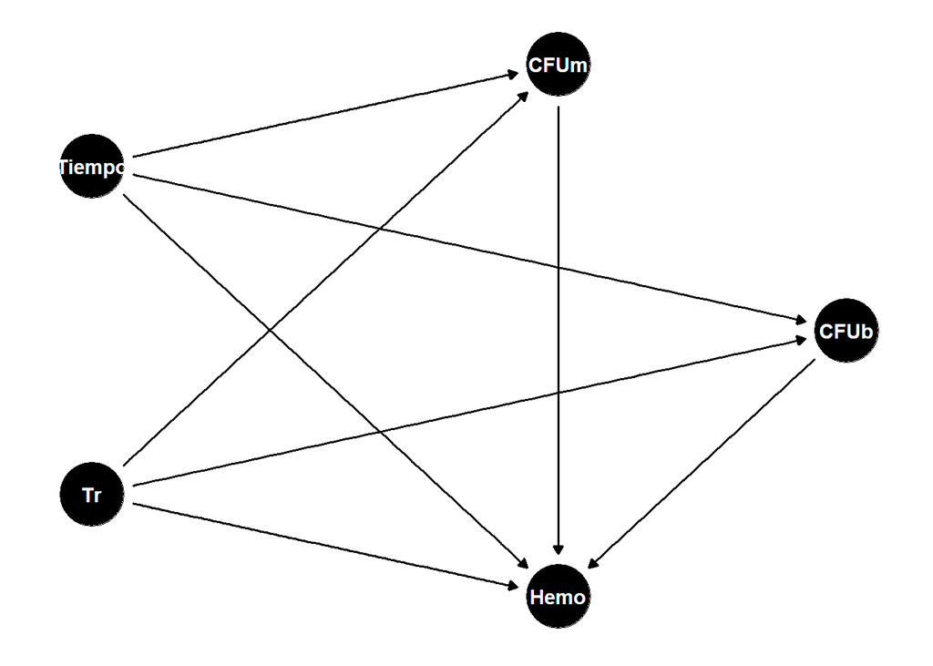

```r
#se grafica el DAG
ggdag(infection, layout = "circle") + theme_dag()
```

Mediante este DAG, se quieren contestar las siguientes preguntas:

1. ¿Cuál es el efecto directo de `Tr` sobre los valores de `Hemo` dependiendo del tiempo de infección (`Tiempo`)?
2. ¿Cuál es el efecto directo de `Tr` sobre la cantidad de `CFUb` dependiendo del tiempo de infección (`Tiempo`)?
3. ¿Cuál es el efecto directo de `Tr` sobre la cantidad de `CFUm` dependiendo del tiempo de infección (`Tiempo`)?

Para responder estas preguntas, es necesario saber cuáles variables se deben **controlar** para conocer el efecto directo de `Tr` sobre las variables respuestas:

```r
#se usa la función 'adjustmentsSets' para enumerar las covariables y se especifica el tipo de efecto que se desea obtener (directo o total) con el argumento 'effect'
adjustmentSets(x = infection, exposure = "Tr", outcome = "Hemo", type="minimal", effect = "direct")
```

```
## { CFUb, CFUm, Tiempo }
```

```r
adjustmentSets(x = infection, exposure = "Tr", outcome = "CFUm", type="minimal", effect = "direct")
```

```
##  {}
```

```r
adjustmentSets(x = infection, exposure = "Tr", outcome = "CFUb", type="minimal", effect = "direct")
```

```
##  {}
```

De acuerdo con este análisis, para determinar el efecto directo de `Tr` sobre `Hemo` se deben controlar en el modelo estadístico las variables `CFUb`, `CFUm` y `Tiempo`, incluyendo la interacción de `Tr` con el `Tiempo`. Para las variables `CFUb` y `CFUm` no es necesario controlar variables, pero sí debe incluirse la interacción `Tr` y `Tiempo` para contestar las preguntas antes planteadas.

#### **3. Procesamiento de los datos**

Antes del análisis de los datos, primero se establece el directorio de trabajo y se lee el archivo de datos crudos con formato csv y se guarda en un objeto:

```r
#se define el directorio de trabajo
setwd("C:/Users/andrearomero/Documents/Andrea - Img, doc, etc/2020/CICLO II-2020/Herramientas prácticas para investigación reproducible/proyecto2/project2_BrucellaPMN/proyecto2_Brucella/proyect2/data/raw")

#R lee el set de datos con la función 'read.csv' y se guarda en un objeto
infection_data <- read.csv("rawdataset.csv", sep = ";")

#verificar que R haya leído y guardado correctamente los datos
View(infection_data)

#cambiar el nombre de la primera columna (T) por Tiempo
colnames(infection_data)[1] <- "Tiempo"
```

Se modifican las variables `Tr` y `Tiempo`para que sean categóricas:

```r
infection_data$Tiempo <- as.factor(infection_data$Tiempo) #la función as.factor cambia una variable numérica a una categórica
infection_data$Tr <- as.factor(infection_data$Tr)
```

#### **4. Análisis de los datos**

Se instalan y cargan las librerías correspondientes a los análisis:

```r
#se cargan librerías
library(ggplot2) #para crear los boxplots
library(dplyr) #para prueba de normalidad y crear modelos de regresión lineal y modelos lineales generalizados
library(tidyverse) #para prueba de homogeneidad de varianzas
library(car) #para utilizar la función Anova
library(ggfortify)
```

##### - Análisis exploratorio

Posteriormente, se hizo una exploración de los datos para visualizar diferencias en las variables respuestas con respecto al tipo de tratamiento, así como datos atípicos.

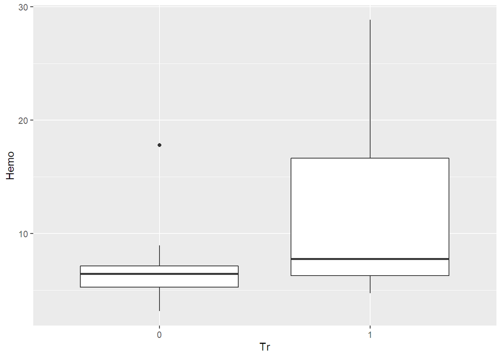

```r
#boxplot para la variable Hemo
ggplot(infection_data, aes(Tr, Hemo)) + geom_boxplot()
```

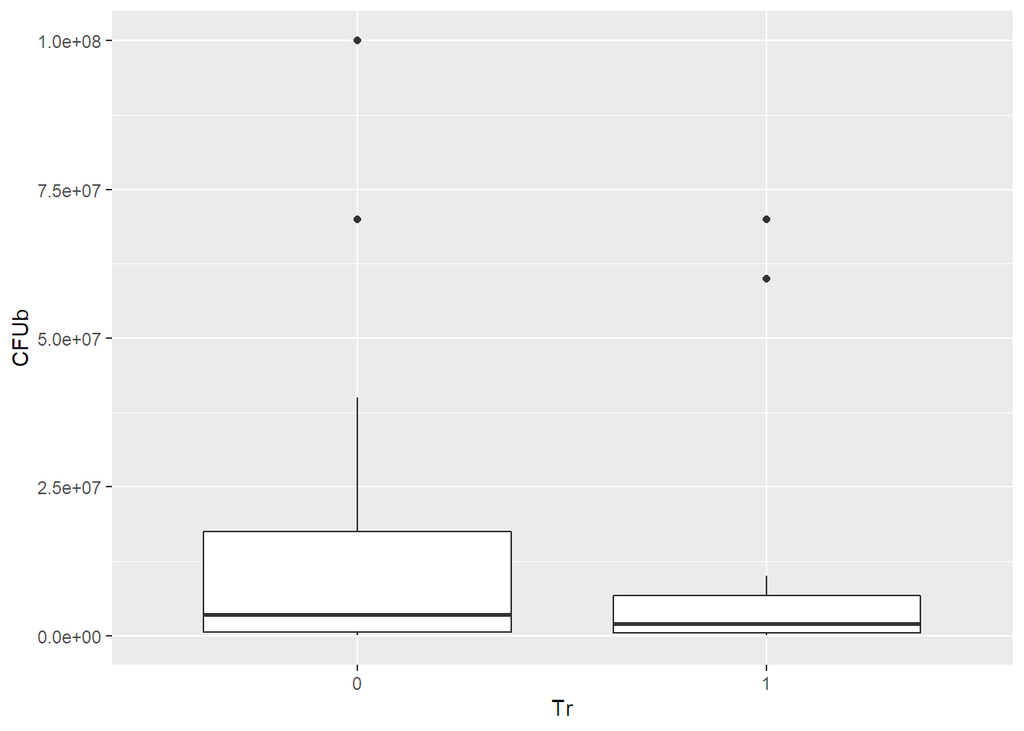

```r
#boxplot para la variable CFUb
ggplot(infection_data, aes(Tr, CFUb)) + geom_boxplot()
```

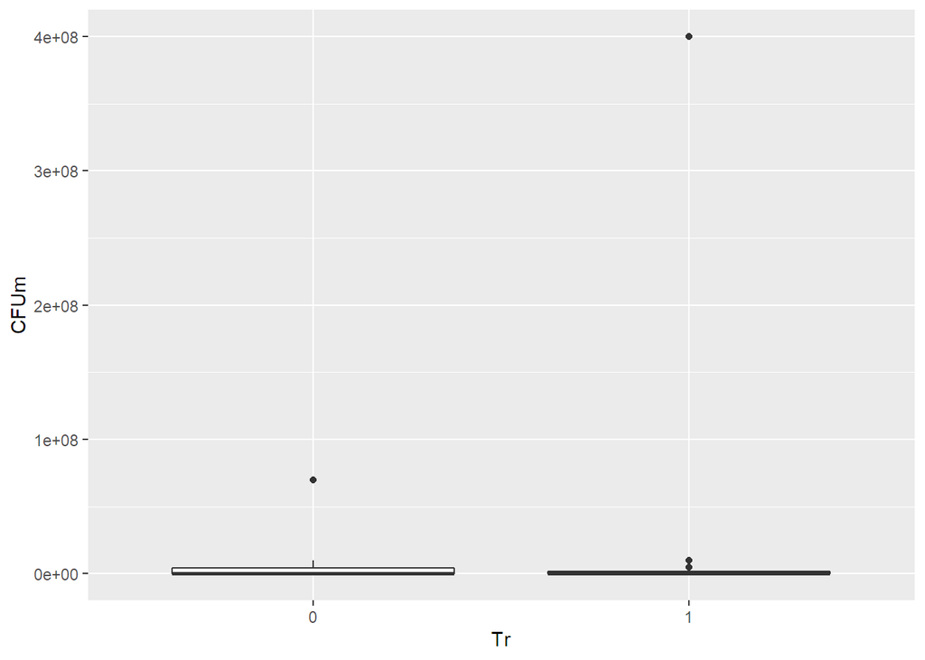

```r
#boxplot para la variable CFUm
ggplot(infection_data, aes(Tr, CFUm)) + geom_boxplot()
```

##### - Evaluación de supuestos

Después de examinar los datos, se consideró utilizar un modelo lineal generalizado, específicamente una distribución de Poisson, ya que se quiere evaluar el efecto de `Tr` sobre las variables respuesta `CFUb` y `CFUm` en diferentes tiempos. Además, los datos son conteos de bacterias (variable discreta). En cambio, para la variable respuesta `Hemo` se consideró utilizar un modelo de regresión lineal por la naturaleza de los datos.

Se evaluaron los supuestos para ambos modelos:

**1. Normalidad.**

Se utilizó la prueba de Shapiro-Wilk para determinar si los datos presentan una distribución normal. Si p es mayor a 0.05, se asume normalidad.

```r
#se realiza la prueba de normalidad para una variable
shapiro.test(infection_data$Hemo) #p < 0.05
```

```
##
##  Shapiro-Wilk normality test
##
## data:  infection_data$Hemo
## W = 0.6559, p-value = 6.139e-08
```

```r
shapiro.test(infection_data$CFUb) #p < 0.05
```

```
##
##  Shapiro-Wilk normality test
##
## data:  infection_data$CFUb
## W = 0.58329, p-value = 6.365e-09
```

```r
shapiro.test(infection_data$CFUm) #p < 0.05
```

```
##
##  Shapiro-Wilk normality test
##
## data:  infection_data$CFUm
## W = 0.22487, p-value = 1.4e-12
```

**2. Homogeneidad de varianzas**

Se escogió la prueba Fligner-Killeen, ya que verifica la homogeneidad de varianzas cuando los datos no están distribuidos normalmente o cuando los problemas relacionados con valores atípicos en el conjunto de datos no se pueden resolver.

```r
#la sintaxis para la función 'fligner.test' corresponde a (respuesta ~ predictora, datos)
fligner.test(Hemo ~ Tr, data = infection_data) #p < 0.05, no se cumple homocedasticidad
```

```
##
##  Fligner-Killeen test of homogeneity of variances
##
## data:  Hemo by Tr
## Fligner-Killeen:med chi-squared = 6.9426, df = 1, p-value = 0.008417
```

```r
fligner.test(CFUb ~ Tr, data = infection_data) #p > 0.05, se cumple homocedasticidad
```

```
##
##  Fligner-Killeen test of homogeneity of variances
##
## data:  CFUb by Tr
## Fligner-Killeen:med chi-squared = 3.5265, df = 1, p-value = 0.06039
```

```r
fligner.test(CFUm ~ Tr, data = infection_data) #p > 0.05, se cumple homocedasticidad
```

```
##
##  Fligner-Killeen test of homogeneity of variances
##
## data:  CFUm by Tr
## Fligner-Killeen:med chi-squared = 0.65518, df = 1, p-value = 0.4183
```

**3. Análisis de residuales**

Otro supuesto para validar los modelos lineales es realizar un ánalisis de residuales, donde se grafique los residuales en función de los valores ajustados por el modelo (i.e. Residuals vs. Fitted). Si el modelo es correcto, el patrón de residuos sería al azar, es decir, que no haya sesgos o tendencias en los residuos ni una dispersión (varianza) no constante ni valores atípicos que desvíen el patrón observado.

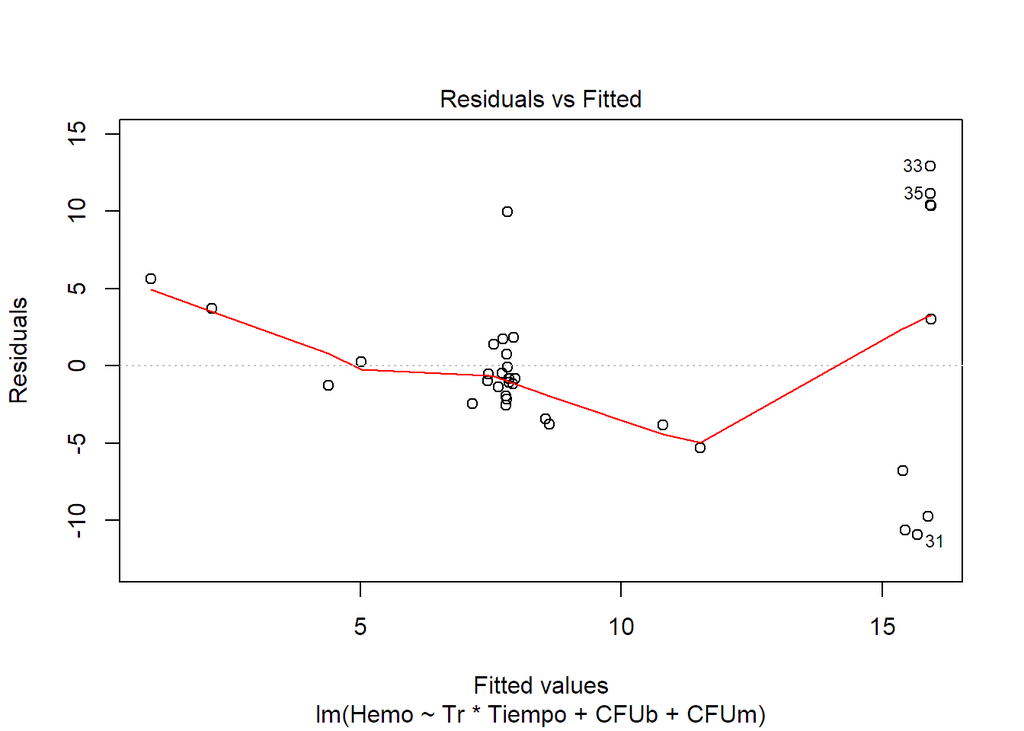

```r
#se utiliza la función lm para regresiones lineales para la variable Hemo (unidades de concentración)
m1 = lm(Hemo ~ Tr * Tiempo + CFUb + CFUm, data = infection_data)

#se grafica Residuales vs Fitted
plot(m1, 1)
```

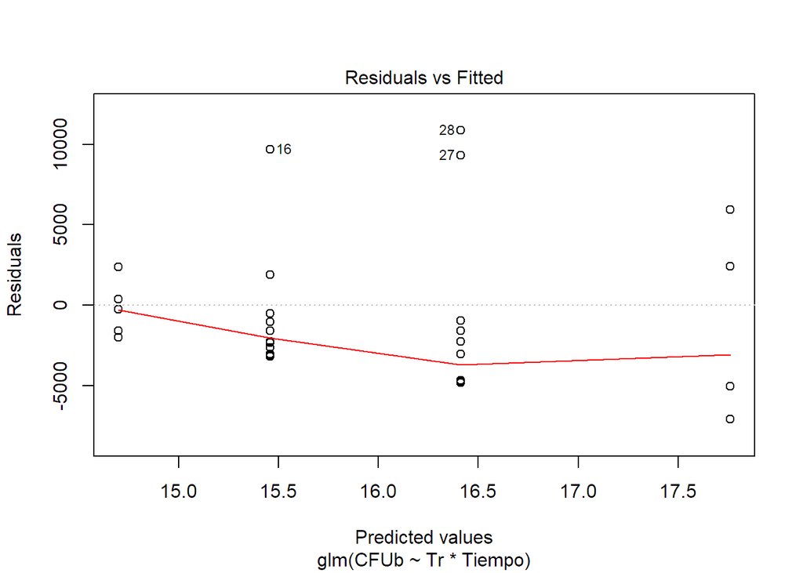

```r
#se utiliza la función glm (modelo lineal generalizado) y se especifica en el modelo el tipo de distribución con el argumento 'familiy'
m2 <- glm(CFUb ~ Tr * Tiempo, family= "poisson", data = infection_data)
#se grafica Residuales vs Fitted
plot(m2, 1)
```

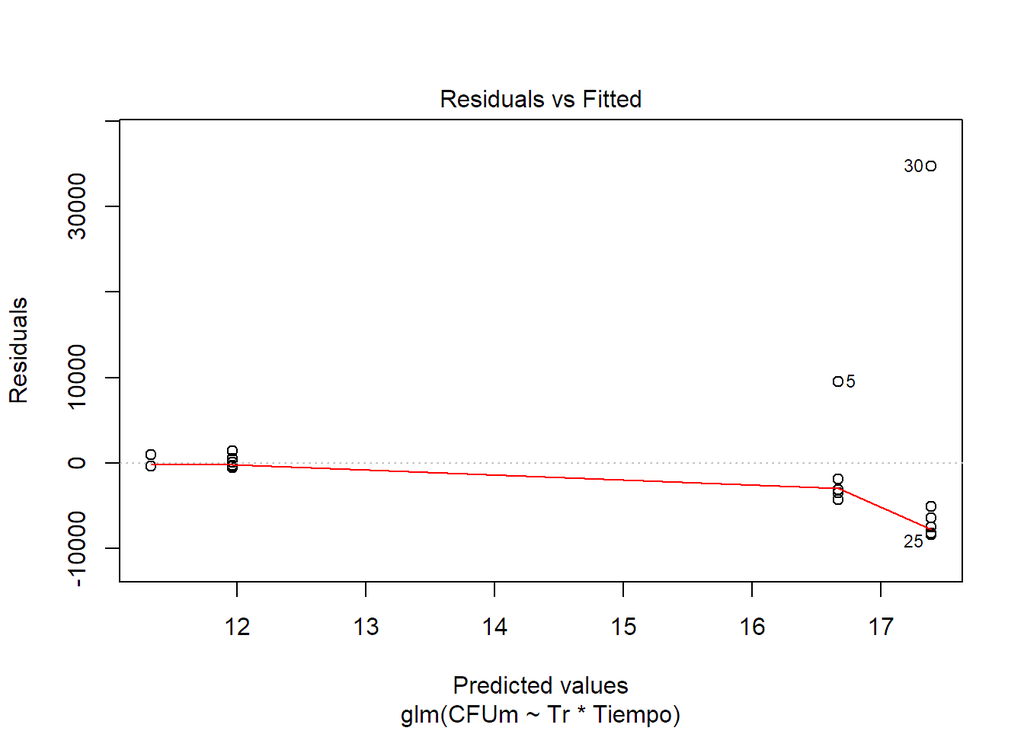

```r
#se utiliza la función glm (modelo lineal generalizado) y se especifica en el modelo el tipo de distribución con el argumento 'familiy'
m3 <- glm(CFUm ~ Tr * Tiempo, family = "poisson", data = infection_data)
#se grafica Residuales vs Fitted
plot(m3, 1)
```

##### - Modelo cuasi Poisson

Debido a que no se cumplieron los supuestos para cada modelo en particular, se decidió realizar un modelo de distribución cuasi Poisson, el cual permite lidiar con la sobre dispersión de los datos y valores atípicos:

- Modelo cuasi Poisson para la variable `CFUb`:

```r
#se utiliza la función 'glm' y se especifica el tipo de distribución para la variable CFUb con el argumento 'family'
m1.1 <- glm(CFUb ~  Tr * Tiempo, family = "quasipoisson", data = infection_data)
summary(m1.1) #compara con el intercepto
```

```
##
## Call:
## glm(formula = CFUb ~ Tr * Tiempo, family = "quasipoisson", data = infection_data)
##
## Deviance Residuals:
##     Min       1Q   Median       3Q      Max
## -7105.5  -3551.6  -2124.1   -116.9  10868.0
##
## Coefficients:
##             Estimate Std. Error t value Pr(>|t|)
## (Intercept)  17.7603     0.3107  57.156  < 2e-16 ***
## Tr1          -3.0624     1.4700  -2.083  0.04530 *
## Tiempo2      -2.3015     0.7608  -3.025  0.00487 **
## Tr1:Tiempo2   4.0156     1.6820   2.387  0.02304 *
## ---
## Signif. codes:  0 '***' 0.001 '**' 0.01 '*' 0.05 '.' 0.1 ' ' 1
##
## (Dispersion parameter for quasipoisson family taken to be 29932504)
##
##     Null deviance: 1259107158  on 35  degrees of freedom
## Residual deviance:  728595149  on 32  degrees of freedom
## AIC: NA
##
## Number of Fisher Scoring iterations: 6
```

```r
Anova(m1.1) #explica si hay un efecto general del tratamiento sobre CFUb dependiendo del tiempo
```

```
## Analysis of Deviance Table (Type II tests)
##
## Response: CFUb
##           LR Chisq Df Pr(>Chisq)
## Tr          2.4109  1   0.120490
## Tiempo      5.1348  1   0.023451 *
## Tr:Tiempo  10.1779  1   0.001421 **
## ---
## Signif. codes:  0 '***' 0.001 '**' 0.01 '*' 0.05 '.' 0.1 ' ' 1
```

Luego, se visualizó la relación de las variables `Tiempo`, `CFUb` y `Tr` en un boxplot:

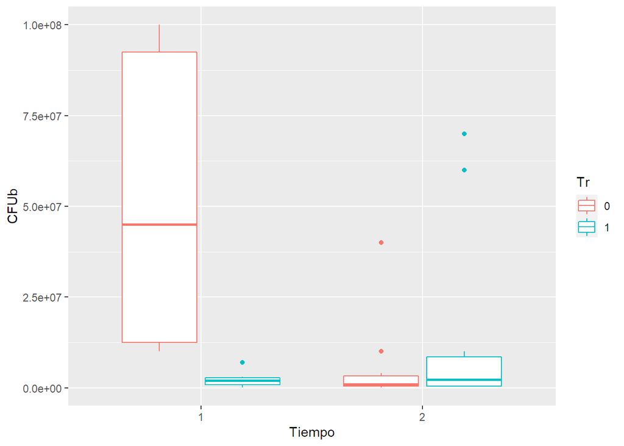

```r
m1.1graph <- ggplot(data=infection_data, aes(x= Tiempo, y = CFUb, colour= Tr)) + geom_boxplot() #dentro del argumento 'aes' se define la variable respuesta CFUb
m1.1graph #se imprime el gráfico
```

- Modelo con distribución cuasi Poisson para la variable `CFUm`:

```r
#se utiliza la función 'glm' y se especifica el tipo de distribución para la variable CFUm con el argumento 'family'
m2.1 <- glm(CFUm ~  Tr * Tiempo, family = "quasipoisson", data = infection_data)
summary(m2.1) #compara con el intercepto
```

```
##
## Call:
## glm(formula = CFUm ~ Tr * Tiempo, family = "quasipoisson", data = infection_data)
##
## Deviance Residuals:
##    Min      1Q  Median      3Q     Max
##  -8442   -5427    -561    -405   34724
##
## Coefficients:
##             Estimate Std. Error t value Pr(>|t|)
## (Intercept)   16.668      1.133  14.713 8.55e-16 ***
## Tr1           -5.338     16.378  -0.326    0.747
## Tiempo2       -4.701      8.480  -0.554    0.583
## Tr1:Tiempo2   10.759     18.417   0.584    0.563
## ---
## Signif. codes:  0 '***' 0.001 '**' 0.01 '*' 0.05 '.' 0.1 ' ' 1
##
## (Dispersion parameter for quasipoisson family taken to be 133479170)
##
##     Null deviance: 2749132250  on 35  degrees of freedom
## Residual deviance: 1989489091  on 32  degrees of freedom
## AIC: NA
##
## Number of Fisher Scoring iterations: 7
```

```r
Anova(m2.1) #explica si hay un efecto general del tratamiento sobre CFUm dependiendo del tiempo
```

```
## Analysis of Deviance Table (Type II tests)
##
## Response: CFUm
##           LR Chisq Df Pr(>Chisq)
## Tr          1.5615  1    0.21145
## Tiempo      0.3741  1    0.54080
## Tr:Tiempo   3.7556  1    0.05263 .
## ---
## Signif. codes:  0 '***' 0.001 '**' 0.01 '*' 0.05 '.' 0.1 ' ' 1
```

Luego, se visualizó la relación de las variables `Tiempo`, `CFUm` y `Tr` en un boxplot:

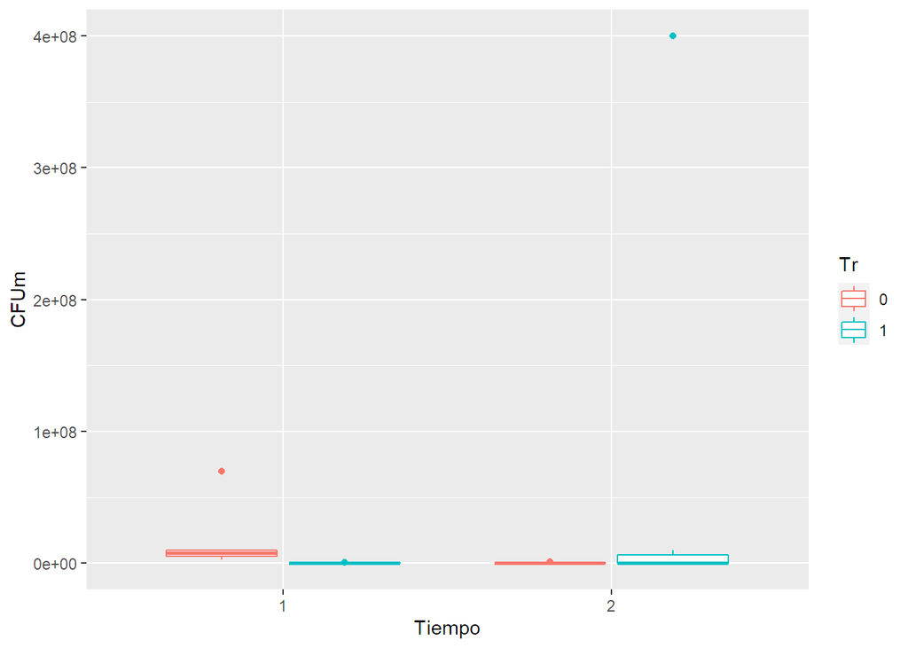

```r
m2.1graph <- ggplot(data=infection_data, aes(x= Tiempo, y = CFUm, colour= Tr)) + geom_boxplot() #dentro del argumento 'aes' se define la variable respuesta CFUm
m2.1graph #se imprime el gráfico
```

- Modelo con distribución cuasi Poisson para la variable `Hemo`:

```r
#se utiliza la función 'glm' y se especifica el tipo de distribución para la variable Hemo con el argumento 'family
m3.1 <- glm(Hemo ~ Tr * Tiempo + CFUm + CFUb, family = "quasipoisson", data = infection_data)
summary(m3.1) #compara con el intercepto
```

```
##
## Call:
## glm(formula = Hemo ~ Tr * Tiempo + CFUm + CFUb, family = "quasipoisson",
##     data = infection_data)
##
## Deviance Residuals:
##     Min       1Q   Median       3Q      Max
## -3.3341  -0.8545  -0.2833   0.5698   3.0604
##
## Coefficients:
##               Estimate Std. Error t value Pr(>|t|)
## (Intercept)  2.130e+00  3.382e-01   6.300 6.05e-07 ***
## Tr1         -5.770e-02  4.096e-01  -0.141   0.8889
## Tiempo2     -7.384e-02  3.705e-01  -0.199   0.8434
## CFUm        -1.856e-09  1.555e-09  -1.193   0.2423
## CFUb        -9.238e-09  4.840e-09  -1.909   0.0659 .
## Tr1:Tiempo2  8.142e-01  4.720e-01   1.725   0.0948 .
## ---
## Signif. codes:  0 '***' 0.001 '**' 0.01 '*' 0.05 '.' 0.1 ' ' 1
##
## (Dispersion parameter for quasipoisson family taken to be 2.675806)
##
##     Null deviance: 141.839  on 35  degrees of freedom
## Residual deviance:  80.106  on 30  degrees of freedom
## AIC: NA
##
## Number of Fisher Scoring iterations: 5
```

```r
Anova(m3.1) #explica si hay un efecto general del tratamiento sobre hemo dependiendo del tiempo
```

```
## Analysis of Deviance Table (Type II tests)
##
## Response: Hemo
##           LR Chisq Df Pr(>Chisq)
## Tr         10.0234  1   0.001546 **
## Tiempo      5.3934  1   0.020213 *
## CFUm        1.7944  1   0.180392
## CFUb        4.1131  1   0.042552 *
## Tr:Tiempo   2.8651  1   0.090522 .
## ---
## Signif. codes:  0 '***' 0.001 '**' 0.01 '*' 0.05 '.' 0.1 ' ' 1
```

Luego, se visualizó la relación de las variables `Tiempo`, `Hemo` y `Tr` en un boxplot:

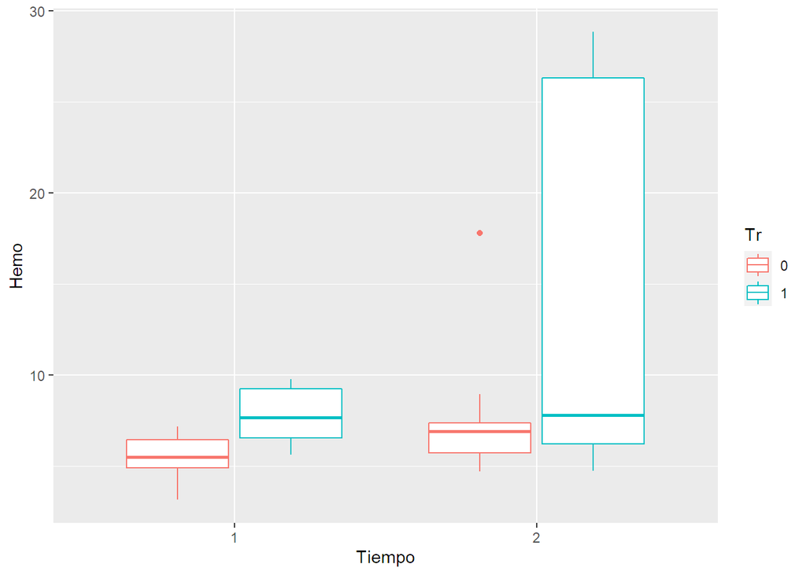

```r
m3.1graph <- ggplot(data=infection_data, aes(x= Tiempo, y = Hemo, colour= Tr)) + geom_boxplot() #dentro del argumento 'aes' se define la variable respuesta Hemo
m3.1graph #se imprime el gráfico
```

#### **6. Referencias bibliográficas**

Dworkin, Martin, Stanley Falkow, Eugene Rosenberg, Karl-Heinz Schleifer, and Erko Stackebrandt. 2006. *The Prokaryotes: A Handbook on the Biology of Bacteria: Vol. 5: Proteobacteria: Alpha and Beta Subclass.* New York: Springer. http://public.ebookcentral.proquest.com/choice/publicfullrecord.aspx?p=3062577.

Moreno, Edgardo, and Elías Barquero-Calvo. 2020. “The Role of Neutrophils in Brucellosis.” *Microbiology and Molecular Biology Reviews* 84 (4): e00048–20, /mmbr/84/4/MMBR.00048–20.atom. https://doi.org/10.1128/MMBR.00048-20.

Roop, R. Martin, Jennifer M. Gaines, Eric S. Anderson, Clayton C. Caswell, and Daniel W. Martin. 2009. “Survival of the Fittest: How Brucella Strains Adapt to Their Intracellular Niche in the Host.” *Medical Microbiology and Immunology* 198 (4): 221–38. https://doi.org/10.1007/s00430-009-0123-8.